# Principios y Prácticas de SEM y MLM (5ed)

Tema 2.1 Análisis Factorial Exploratorio (EFA)

Author

Affiliation

Efraín García Sánchez

CIMCYC — Universidad de Granada

Published

May 15, 2026

# Principios

## ¿Qué son los Análisis Factoriales Exploratorios?

- En ciencia se miden constructos o fenómenos que no se pueden acceder directamente
  - **Variables latentes** (vs. variables observadas)
  - Usualmente se miden diferentes **indicadores** del constructo

> Es una técnica estadística multivariada que se usa para identificar si un conjunto amplio de variables observadas puede resumirse en un número menor de factores latentes. Busca identificar la *estructura subyacente* de los datos basado en las correlaciones entre los ítems.

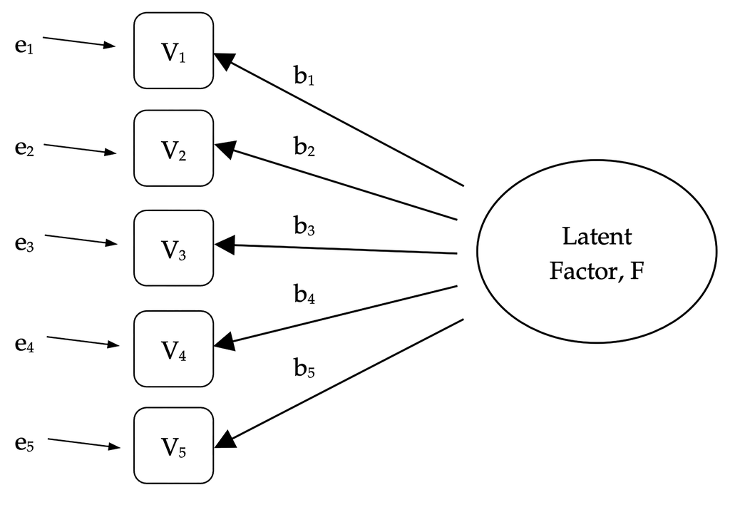

## ¿Cuándo se usan los análisis factoriales exploratorios (EFA)?

- Reducir datos (*parsimonia*)
  - Reduce los datos y conserva la mayor cantidad de información
- Comprender la estructura de un conjunto de variables
  - Identificando grupos de variables asociadas entre sí (*componentes/factores*)
  - Identifica los ítems que comparten varianza (en una matriz de correlación)
- Construir cuestionarios o instrumentos de medición
  - Dimensionalidad, fiabilidad y validez.
  - Complementario a técnicas de IRT

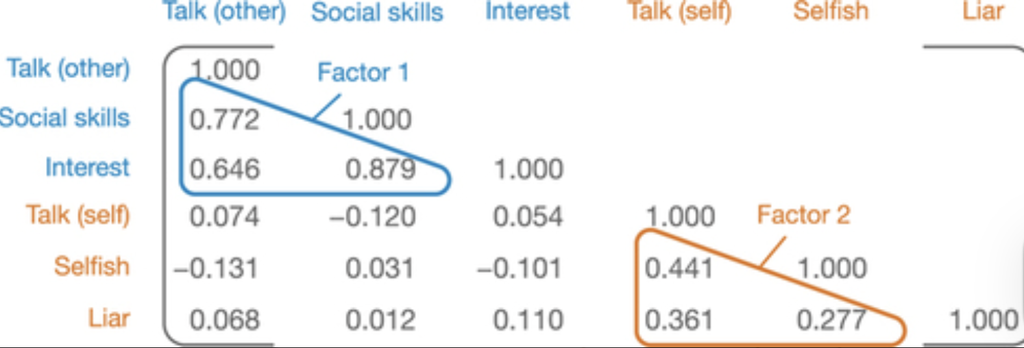

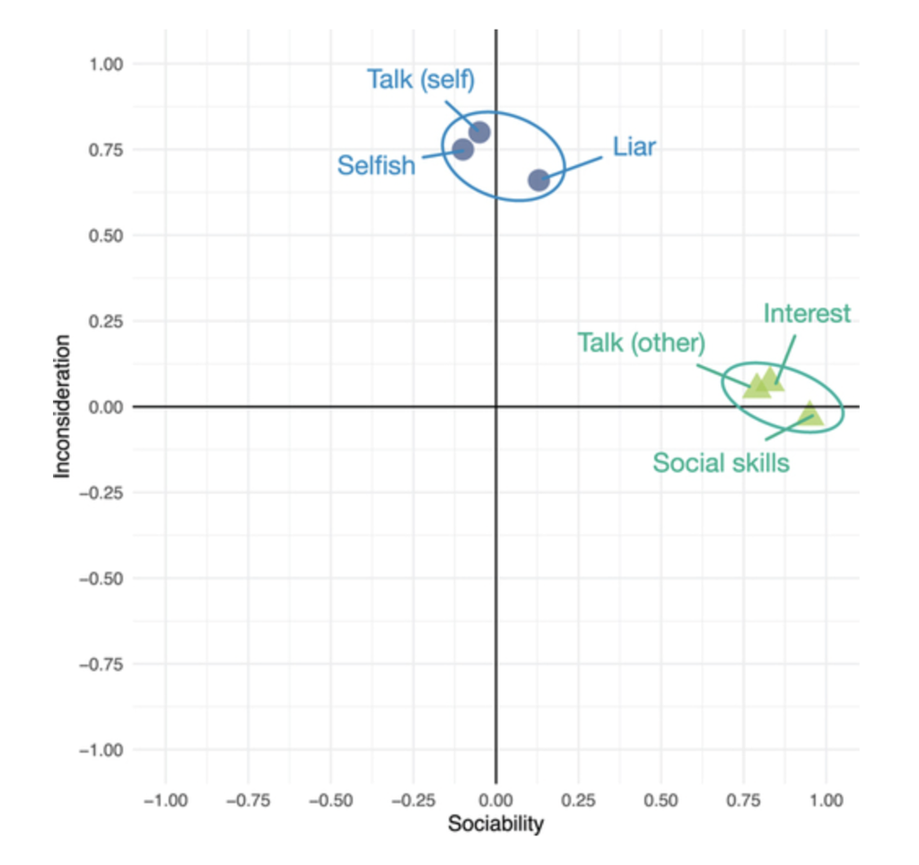

## Diferencias entre Análisis Factorial (FA) y Análisis de componentes principales (PCA)?

**FA**

- Explicar la **varianza común**
- Otras fuentes de **varianza (e.g, error)**
- El **factor causa o explica** el indicador (*reflective*)
- **Inferencial** (ej., teoría subyacente)
- Más apropiado para **representar constructos**
- Más sensible a supuestos estadísticos

**PCA**

- Explicar la **varianza total**
- No contempla error de medida
- Los **indicares causan o predicen el componente** (*formative*)
- **Descriptivo** (ej., identifica clusters)
- Más apropiado para **reducir datos**
- Más parsimonioso y menos susceptible de soluciones impropias

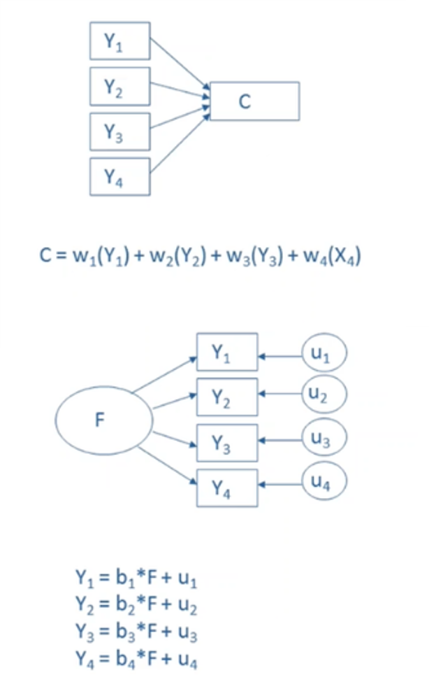

## Diferencias entre PCA y Análisis Factoriales

**Análisis de Componentes Principales**

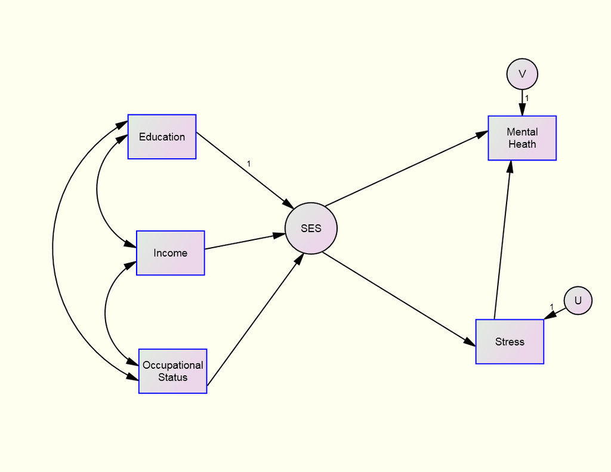

**Análisis Factorial Exploraotrio**

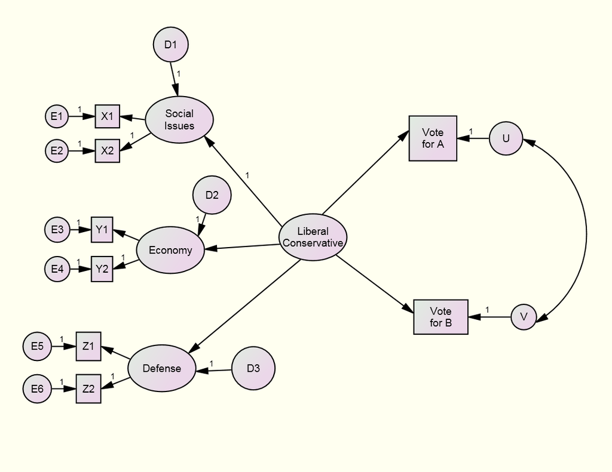

Source: [David Kenny](https://davidakenny.net/cm/mvar.htm)

## Modelo factorial con medias

#### Fórmula con dos factores

$$\mathbf{X} = \boldsymbol{\mu} + \boldsymbol{\Lambda}\mathbf{F} + \boldsymbol{\varepsilon}$$

Para una variable observada:

$$X_i = \mu_i + \lambda_{i1}F_1 + \lambda_{i2}F_2 + \varepsilon_i$$

#### Convenciones

- $\mathbf{X}$: vector de variables observadas
- $\boldsymbol{\mu}$: vector de medias/interceptos de las variables
- $\boldsymbol{\Lambda}$: matriz de cargas factoriales
- $\mathbf{F}$: vector de factores latentes
- $\boldsymbol{\varepsilon}$: error o varianza específica

#### Matriz de cargas factoriales (equiparables a coeficientes de regresión) $\boldsymbol{\Lambda}$

$$\boldsymbol{\Lambda} =
\begin{bmatrix}
\lambda_{11} & \lambda_{12} \\
\lambda_{21} & \lambda_{22} \\
\lambda_{31} & \lambda_{32} \\
\vdots & \vdots \\
\lambda_{p1} & \lambda_{p2}
\end{bmatrix}$$

## ¿Cuándo usar EFA o PCA?

**Depende de…**

| Criterio | Usar PCA cuando… | Usar EFA cuando… |
| --- | --- | --- |
| **Pregunta de investigación** | El objetivo es **reducir datos** o describir la estructura empírica de los indicadores. | El objetivo es **identificar factores latentes** que expliquen las relaciones entre los indicadores. |
| **Naturaleza del fenómeno** | El fenómeno es principalmente **observable** y está representado directamente en los datos. | El fenómeno es **latente** y se infiere a partir del patrón de relaciones entre los datos. |
| **Conceptualización del constructo** | El constructo se entiende como **formativo**: es el resultado de combinar varios indicadores. | El constructo se entiende como **reflectivo**: el factor latente causa o explica las respuestas a los indicadores. |

**Note**

En términos generales, **PCA** resume información observada, mientras que **EFA/EFA** busca modelar factores latentes.

## ¿Cuándo usar EFA o PCA? Ejemplo

- **Reflective** (izquierda) –> Actitud positiva hacia el servicio = cause o predice creencias o intenciones de conducta
- **Formative** (derecha) –> Satisfacción con un servicio = la combinación de valoraciones positivas sobre diferentes aspectos

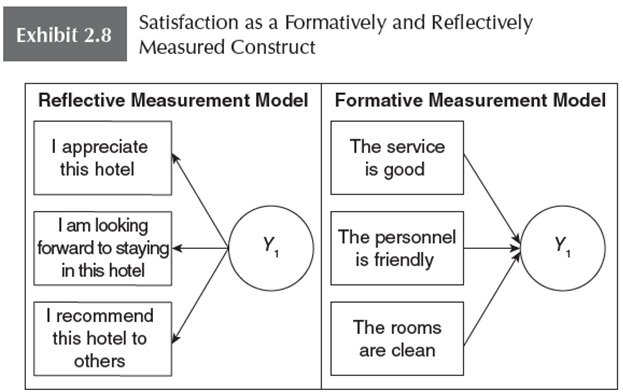

- Depende
  - de la pregunta de investigación
    - Si busca reducir datos o describir el constructo –> PCA
    - Si busca identificar factores latentes –> FA
  - de la naturaleza del fenómeno
    - Si es algo observable (está presente en los datos) –> PCA
    - Si es algo latente (se infiere a partir de los datos –> FA
  - de la conceptualización del constructo
    - Formativo: Si el constructo es el resultado de los indicadores –> PCA
    - Reflectivo: Si el constructo **causa** los indicadores –> EFA

## Procedimiento para un EFA (aplican para un PCA)

- Decisiones metodológicas ([Fabrigar et al., 1999](https://www.statpower.net/Content/312/Handout/Fabrigar1999.pdf))
1. Decidir las variables que va a incluir
2. Determinar si el EFA es el método apropiado
3. Seleccionar procedimiento apropiado de estimación (ajustar el modelo a los datos)
4. Decidir cuántos factores incluir en el modelo
5. Seleccionar un método de rotación apropiado

**Extra:** Intepretar la estructura a la luz de la teoría (hipótesis) y los datos (ajuste del modelo)

**Note**

Vamos a revisar estas decisiones sobre la práctica

# Práctica

## Instalar nuevos paquetes

```r
install.packages("psychTools")
```

## Cargar los paquetes

```r
library(tidyverse)        # manipulación y visualización de datos
library(easystats)        # Paquetes para análisis estadísticos
library(sjPlot)           # para visualización de resultados, tables y figuras
library(sjmisc)           # funciones para manipulación de datos
library(psych)            # para análisis psicométricos
library(psychTools)       # para extensiones del paquete psych
```

## Importar los datos: con etiquetas (para conservar los labels)

```r
data_labels <- haven::read_sav(
  here::here("data",
  "northampton_student_health_data_package",
  "northampton_student_health_labelled.sav"))

glimpse(data_labels)
```

```
Rows: 590
Columns: 61
$ id                             <dbl> 1, 2, 3, 4, 5, 6, 7, 8, 9, 10, 11, 12, …
$ age_group                      <dbl+lbl> 1, 1, 1, 1, 1, 1, 2, 4, 1, 1, 1, 1,…
$ gender                         <dbl+lbl> 2, 1, 1, 1, 1, 2, 1, 1, 2, 2, 2, 2,…
$ sexual_orientation             <dbl+lbl> 1, 2, 1, 3, 1, 1, 1, 1, 1, 1, 1, 1,…
$ ethnicity                      <dbl+lbl> 1, 1, 1, 2, 1, 3, 1, 1, 1, 3, 1, 1,…
$ study_mode                     <dbl+lbl> 1, 1, 1, 1, 1, 1, 1, 2, 1, 1, 1, 1,…
$ study_level                    <dbl+lbl> 3, 3, 3, 3, 2, 6, 4, 3, 1, 2, 1, 1,…
$ living_situation               <dbl+lbl> 1, 2, 1, 3, 2, 4, 3, 3, 1, 2, 4, 1,…
$ phys_health                    <dbl+lbl> 3, 4, 4, 3, 4, 5, 5, 1, 4, 4, 4, 5,…
$ ment_health                    <dbl+lbl> 4, 3, 2, 4, 3, 3, 2, 1, 4, 4, 3, 5,…
$ social_connect                 <dbl+lbl> 4, 3, 1, 1, 2, 3, 2, 4, 4, 3, 3, 3,…
$ sitting_weekday_hours          <dbl> 8, 5, 7, 9, NA, 5, 11, 13, 6, 5, 12, 6,…
$ sleep_quality                  <dbl> 8, 7, 4, 7, 2, 5, 3, 8, 7, 2, 9, 7, 3, …
```

[output cut: 48 more lines]

## Importar los datos: solo numéricos (recomendado para evitar conflictos con paquetes)

```r
data <- readr::read_csv(
  here::here("data",
  "northampton_student_health_data_package",
  "northampton_student_health_numeric.csv"))

glimpse(data)
```

```
Rows: 590
Columns: 61
$ id                             <dbl> 1, 2, 3, 4, 5, 6, 7, 8, 9, 10, 11, 12, …
$ age_group                      <dbl> 1, 1, 1, 1, 1, 1, 2, 4, 1, 1, 1, 1, 1, …
$ gender                         <dbl> 2, 1, 1, 1, 1, 2, 1, 1, 2, 2, 2, 2, 2, …
$ sexual_orientation             <dbl> 1, 2, 1, 3, 1, 1, 1, 1, 1, 1, 1, 1, 1, …
$ ethnicity                      <dbl> 1, 1, 1, 2, 1, 3, 1, 1, 1, 3, 1, 1, 1, …
$ study_mode                     <dbl> 1, 1, 1, 1, 1, 1, 1, 2, 1, 1, 1, 1, 1, …
$ study_level                    <dbl> 3, 3, 3, 3, 2, 6, 4, 3, 1, 2, 1, 1, 1, …
$ living_situation               <dbl> 1, 2, 1, 3, 2, 4, 3, 3, 1, 2, 4, 1, 1, …
$ phys_health                    <dbl> 3, 4, 4, 3, 4, 5, 5, 1, 4, 4, 4, 5, 5, …
$ ment_health                    <dbl> 4, 3, 2, 4, 3, 3, 2, 1, 4, 4, 3, 5, 3, …
$ social_connect                 <dbl> 4, 3, 1, 1, 2, 3, 2, 4, 4, 3, 3, 3, 2, …
$ sitting_weekday_hours          <dbl> 8, 5, 7, 9, NA, 5, 11, 13, 6, 5, 12, 6,…
$ sleep_quality                  <dbl> 8, 7, 4, 7, 2, 5, 3, 8, 7, 2, 9, 7, 3, …
```

[output cut: 48 more lines]

## Seleccionar un subconjunto de datos para el EFA

- Asumimos que preparar la comida es un indicador de un factor latente
  - Por ejemplo: Dependencia en la alimentación
- Item: *Who primarily PREPARES your food and/or meals?* (Yes = 1; No = 0)
- Opciones: “self” “parent_caregiver” “partner” “friends” “housemates” “other_family” “other” “none”

```r
data_prepare <- data |>
  dplyr::select(starts_with("food_prepare_")) # selecciona todas las variables que empiezan con "food_prepare_"

# revisamos los nombre
names(data_prepare)
```

```
[1] "food_prepare_self"             "food_prepare_parent_caregiver"
[3] "food_prepare_partner"          "food_prepare_friends"
[5] "food_prepare_housemates"       "food_prepare_other_family"
[7] "food_prepare_other"            "food_prepare_none"
```

#### Decisiones

- Seleccionar ítems que sean relevantes teóricamente
- Evitar ítems que NO tengan ninguna variabilidad o relación alguna con otros ítems

## Revisamos los datos que vamos a incluir: análisis descriptivos

```r
psych::describe(data_prepare)
```

```
                              vars   n mean   sd median trimmed mad min max
food_prepare_self                1 590 0.89 0.32      1    0.98   0   0   1
food_prepare_parent_caregiver    2 590 0.11 0.31      0    0.01   0   0   1
food_prepare_partner             3 590 0.14 0.34      0    0.05   0   0   1
food_prepare_friends             4 590 0.02 0.15      0    0.00   0   0   1
food_prepare_housemates          5 590 0.03 0.16      0    0.00   0   0   1
food_prepare_other_family        6 590 0.04 0.19      0    0.00   0   0   1
food_prepare_other               7 590 0.04 0.19      0    0.00   0   0   1
food_prepare_none                8 590 0.00 0.04      0    0.00   0   0   1
                              range  skew kurtosis   se
food_prepare_self                 1 -2.43     3.91 0.01
food_prepare_parent_caregiver     1  2.51     4.32 0.01
food_prepare_partner              1  2.10     2.42 0.01
food_prepare_friends              1  6.50    40.26 0.01
food_prepare_housemates           1  5.81    31.78 0.01
food_prepare_other_family         1  5.00    23.04 0.01
food_prepare_other                1  4.87    21.77 0.01
food_prepare_none                 1 24.17   583.01 0.00
```

#### Diagnóstico

- Hay una variable que sólo ha respondido 1 persona `food_prepare_none`.

#### Decisiones

- Eliminamos ítems o variables que no son relevantes o no tienen variabilidad

```r
data_prepare <- data_prepare |>
  select(-food_prepare_none) # para eliminar una variable - o !

# revisamos
names(data_prepare)
```

```
[1] "food_prepare_self"             "food_prepare_parent_caregiver"
[3] "food_prepare_partner"          "food_prepare_friends"
[5] "food_prepare_housemates"       "food_prepare_other_family"
[7] "food_prepare_other"
```

## Revisamos los datos que vamos a incluir: revisamos items invertidos

- Si el constructo es *depenencia*, entonces preparar comida para sí mismo debería estar invertido (cuanto menos preparo mi comida, más dependiente)

#### Decisiones

- Invertir items que reflejen una característica a favor (o en contra) del constructo
- **Buena práctica**: Organizar todos los datos en el formato correcto desde el principio

[figure not shown]

```r
data_prepare <- data_prepare |>
  datawizard::reverse(select = "food_prepare_self",
                      range = c(0,1))
```

**Note**

- Se pueden revertir los items de muchas maneras
- Recordar nunca modificar los datos originales (estamos trabajando sobre un subconjunto de datos)

## Revisamos los datos que vamos a incluir: ver distribuciones

- Ver distribuciones de los datos

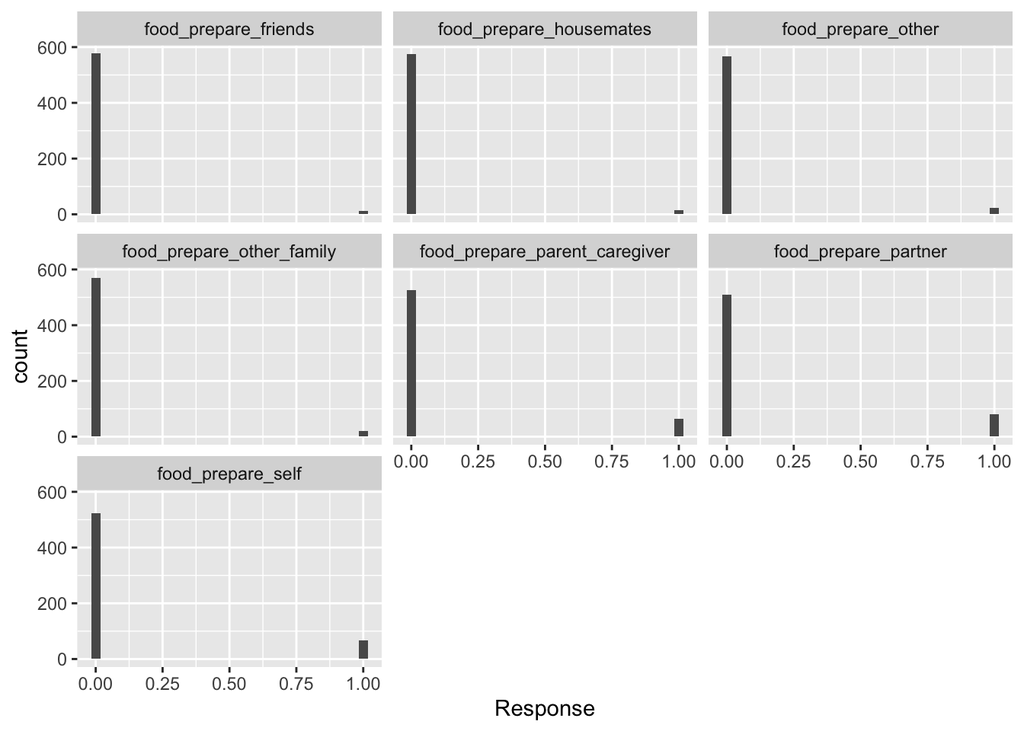

```r
data_prepare |>
  tidyr::pivot_longer(
    cols = 1:7,
    names_to = "Item",
    values_to = "Response"
  ) |>
  ggplot2::ggplot(mapping = aes(Response)) +
  geom_histogram() +
  facet_wrap(~ Item)
```

## ¿Los datos son apropiados para un EFA? Inspección manual

- Muy importante usar los datos apropiados: *garbage in, garbage out*
- Los indicadores deben estar correlacionados
- Dos problemas:
  - Relaciones muy bajas (cerca de cero, **r < 0.05**
  - Relaciones muy altas (cerca de uno, **r > 0.90**
- Usar el método correcto para estimar las correlaciones (depende de las naturaleza de los datos).
  - Continuas: Pearson (**method = pearson**)
  - Ordinales: Policóricas (**method = polychoric**)
  - Dicotómicas: Tetracóricas (**method = tetrachoric**)

**Calculamos las correlaciones**

```r
data_cor <- data_prepare |>
  correlation::correlation(method = "tetrachoric") # porque usamos variables dicotómicas; dejar en blanco si se usa Pearson
```

[output not shown]

- Examinamos los resultados

```r
data_cor |>
  correlation::display()
```

Correlation Matrix (tetrachoric-method)

| Parameter1 | Parameter2 | rho | 95% CI | t(588) | p |
| --- | --- | --- | --- | --- | --- |
| food_prepare_self | food_prepare_parent_caregiver | 0.65 | (0.60, 0.70) | 20.89 | < .001*** |
| food_prepare_self | food_prepare_partner | 0.50 | (0.43, 0.56) | 13.87 | < .001*** |
| food_prepare_self | food_prepare_friends | -0.09 | (-0.17, -8.73e-03) | -2.18 | 0.180 |
| food_prepare_self | food_prepare_housemates | 0.03 | (-0.06, 0.11) | 0.61 | > .999 |
| food_prepare_self | food_prepare_other_family | 0.53 | (0.47, 0.58) | 15.00 | < .001*** |
| food_prepare_self | food_prepare_other | 0.55 | (0.50, 0.61) | 16.16 | < .001*** |
| food_prepare_parent_caregiver | food_prepare_partner | -0.03 | (-0.11, 0.05) | -0.81 | > .999 |
| food_prepare_parent_caregiver | food_prepare_friends | -0.08 | (-0.16, 2.13e-03) | -1.91 | 0.282 |
| food_prepare_parent_caregiver | food_prepare_housemates | -0.13 | (-0.20, -0.04) | -3.06 | 0.021* |
| food_prepare_parent_caregiver | food_prepare_other_family | -0.31 | (-0.38, -0.23) | -7.81 | < .001*** |
| food_prepare_parent_caregiver | food_prepare_other | -0.32 | (-0.39, -0.24) | -8.06 | < .001*** |
| food_prepare_partner | food_prepare_friends | -0.27 | (-0.34, -0.19) | -6.74 | < .001*** |
| food_prepare_partner | food_prepare_housemates | -0.31 | (-0.38, -0.23) | -7.80 | < .001*** |
| food_prepare_partner | food_prepare_other_family | -0.24 | (-0.32, -0.16) | -6.04 | < .001*** |
| food_prepare_partner | food_prepare_other | -0.25 | (-0.33, -0.17) | -6.32 | < .001*** |
| food_prepare_friends | food_prepare_housemates | 0.54 | (0.48, 0.60) | 15.65 | < .001*** |
| food_prepare_friends | food_prepare_other_family | 3.43e-03 | (-0.08, 0.08) | 0.08 | > .999 |
| food_prepare_friends | food_prepare_other | -5.28e-03 | (-0.09, 0.08) | -0.13 | > .999 |
| food_prepare_housemates | food_prepare_other_family | 0.12 | (0.04, 0.20) | 2.97 | 0.025* |
| food_prepare_housemates | food_prepare_other | 0.11 | (0.03, 0.19) | 2.72 | 0.047* |
| food_prepare_other_family | food_prepare_other | 1.00 | (1.00, 1.00) | 582.45 | < .001*** |

p-value adjustment method: Holm (1979) Observations: 590

#### Decisión

- Examinamos el resultado
- Dos ítems correlacionan de forma perfecta (error en los datos).

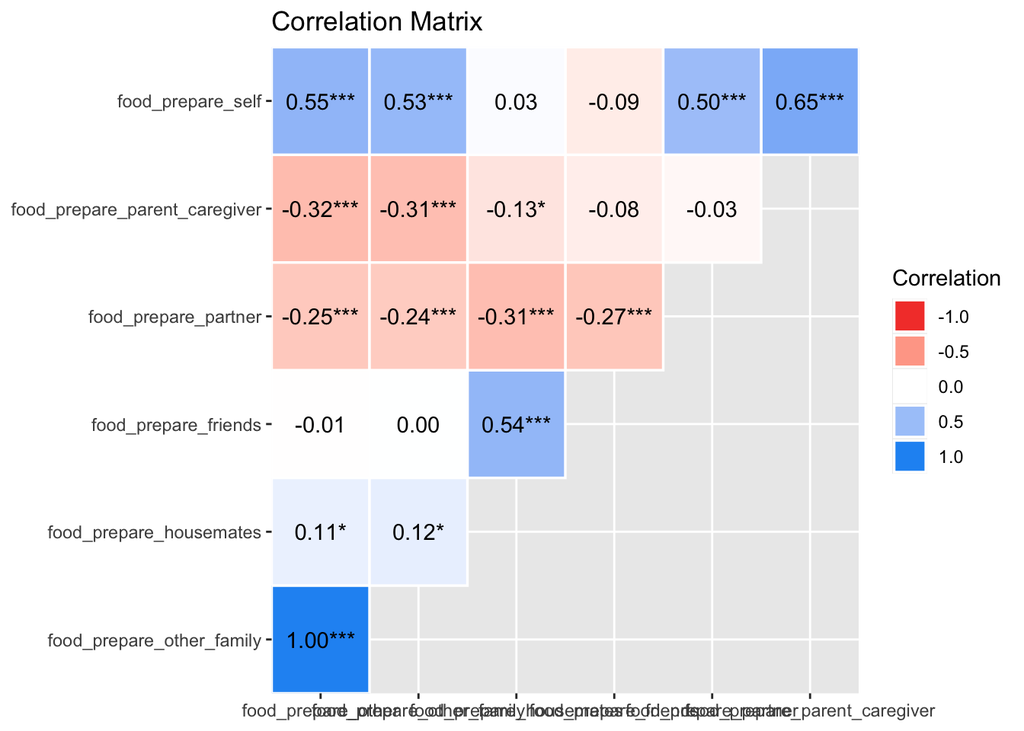

```r
data_cor |>
  summary() |>
  plot()
```

- Eliminar uno de los ítems problemáticos y volvemos a crear la matriz de correlaciones

```r
data_prepare <- data_prepare |>
  select(-food_prepare_other)

# verificamos
names(data_prepare)
```

```
[1] "food_prepare_self"             "food_prepare_parent_caregiver"
[3] "food_prepare_partner"          "food_prepare_friends"
[5] "food_prepare_housemates"       "food_prepare_other_family"
```

- Volvemos a crear la matriz de correlaciones
- Sigue habiendo problemas (correlaciones muy bajas)
- Debemos parar, pero seguimos adelante con fines pedagógicos

```r
data_cor <- data_prepare |>
  correlation::correlation(method = "tetrachoric")
```

```
For i = 2 j = 1  A cell entry of 0 was replaced with correct =  0.5.  Check your data!
For i = 2 j = 1  A cell entry of 0 was replaced with correct =  0.5.  Check your data!
For i = 2 j = 1  A cell entry of 0 was replaced with correct =  0.5.  Check your data!
For i = 2 j = 1  A cell entry of 0 was replaced with correct =  0.5.  Check your data!
```

- Inspeccionamos

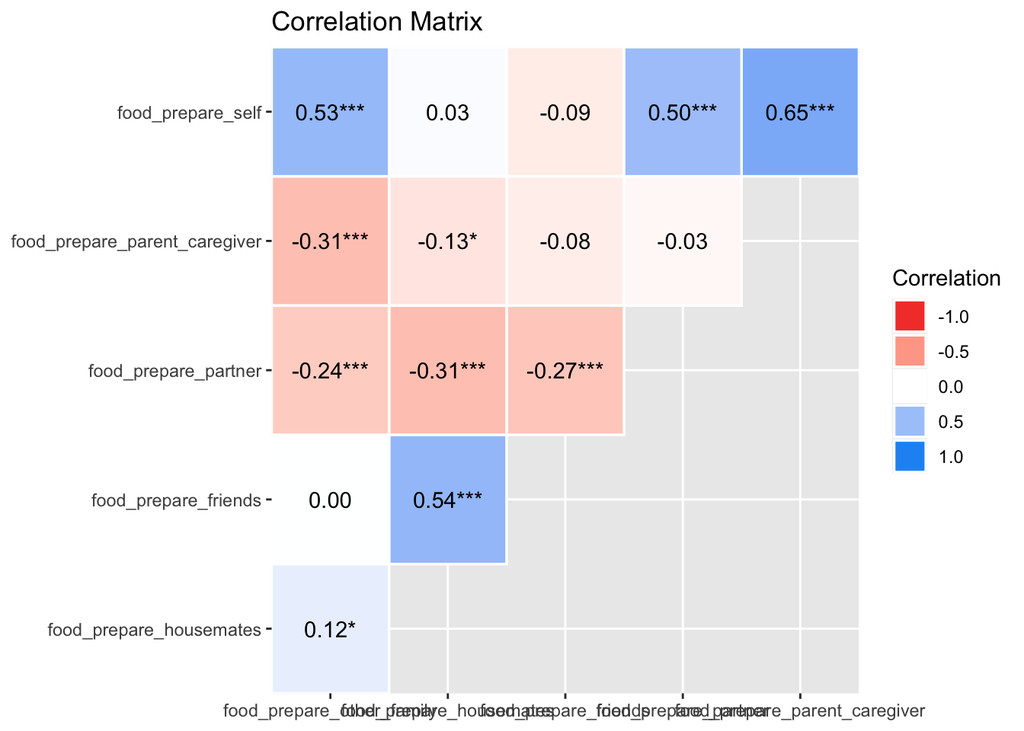

```r
data_cor |>
  summary() |>
  plot()
```

- Convertimos las correlaciones en una matriz (para facilitar análisis posteriores)

```r
data_cor_mtx <- as.matrix(data_cor)

# Mostrar la matriz de correlaciones
round(data_cor_mtx, 2)
```

```
                              food_prepare_self food_prepare_parent_caregiver
food_prepare_self                          1.00                          0.65
food_prepare_parent_caregiver              0.65                          1.00
food_prepare_partner                       0.50                         -0.03
food_prepare_friends                      -0.09                         -0.08
food_prepare_housemates                    0.03                         -0.13
food_prepare_other_family                  0.53                         -0.31
                              food_prepare_partner food_prepare_friends
food_prepare_self                             0.50                -0.09
food_prepare_parent_caregiver                -0.03                -0.08
food_prepare_partner                          1.00                -0.27
food_prepare_friends                         -0.27                 1.00
food_prepare_housemates                      -0.31                 0.54
food_prepare_other_family                    -0.24                 0.00
                              food_prepare_housemates food_prepare_other_family
food_prepare_self                                0.03                      0.53
food_prepare_parent_caregiver                   -0.13                     -0.31
food_prepare_partner                            -0.31                     -0.24
food_prepare_friends                             0.54                      0.00
food_prepare_housemates                          1.00                      0.12
food_prepare_other_family                        0.12                      1.00
```

## ¿Los datos son apropiados para un EFA? Tests formales

#### Medida de Kayser-Meyer-Olking

- Prueba si los datos son apropiados PCA/FA
  - $KMO = 0$ datos inapropiados (mucha difusión en el patrón de correlaciones).
  - $KMO = 1$ datos apropiados (correlaciones compactas)
- Criterios:
  - $KMO > 0.8$ Excelente
  - $0.8 < KMO > 0.7$ Bueno
  - $0.7 < KMO > 0.6$ Mediocre
  - $KMO < 0.5$ Malo

```r
# KMO
psych::KMO(data_cor)
```

```
Error in solve.default(r) :
  system is computationally singular: reciprocal condition number = 9.5165e-18
```

```
Kaiser-Meyer-Olkin factor adequacy
Call: psych::KMO(r = data_cor)
Overall MSA =  0.5
MSA for each item =
            food_prepare_self food_prepare_parent_caregiver
                          0.5                           0.5
         food_prepare_partner          food_prepare_friends
                          0.5                           0.5
      food_prepare_housemates     food_prepare_other_family
                          0.5                           0.5
```

#### Test de Bartlett

- Examina si la matriz de correlaciones es significativamente diferente de una matriz de identidad (identity matrix)
  - Si es significativo (p<0.05) = las correlaciones entre las variables son (en general) significativamente diferentes de cero.
  - Sensible al tamaño de la muestra (significativo con muestras grandes)

```r
# test de Bartlett
cortest.bartlett(R = data_cor,  # usa la matriz de correlación
                 n = 590)       # tamaño de la muestra
```

```
$chisq
[1] 433.4916

$p.value
[1] 6.21172e-83

$df
[1] 15
```

## ¿Los datos son apropiados para un EFA? Tests formales

- Los datos no son apropiados (no debemos seguir, pero seguimos con fines pedagógicos)

```r
performance::check_factorstructure(data_prepare)
```

```
# Is the data suitable for Factor Analysis?


  - Sphericity: Bartlett's test of sphericity suggests that there is sufficient significant correlation in the data for factor analysis (Chisq(15) = 221.63, p < .001).
  - KMO: The Kaiser, Meyer, Olkin (KMO) overall measure of sampling adequacy suggests that factor analysis is likely to be inappropriate (KMO = 0.39). The individual KMO scores are: food_prepare_self (0.42*), food_prepare_parent_caregiver (0.38*), food_prepare_partner (0.35*), food_prepare_friends (…
```

## `Scree plot` y `parallel análisis` Identificar el número de factores

- `Scree plot`
  - Identifica los factores a partir de los `eigenvalues`
  - Factores hasta el punto de inflexión (punto de inflexión no incluido)
- `Parallel analysis`
  - Prueba que indica cuantos `eigenvalues` se identifican por encima del azar

## `parallel análisis`: Identificar el número de factores

- Prueba que indica cuantos `eigenvalues` se identifican por encima del azar
- Determina el número adecuado de factores (y componentes) basado en los factores que están por encima de las líneas rojas (datos simulados)

```r
psych::fa.parallel(data_prepare,
                   fm = "minres", # Minimal residuals
                   cor = "tet",   # porque los items son dicotómicos
                   fa = "fa")   # para PCA sólo cambiar a "pca" o "both"
```

```
Parallel analysis suggests that the number of factors =  4  and the number of components =  NA
```

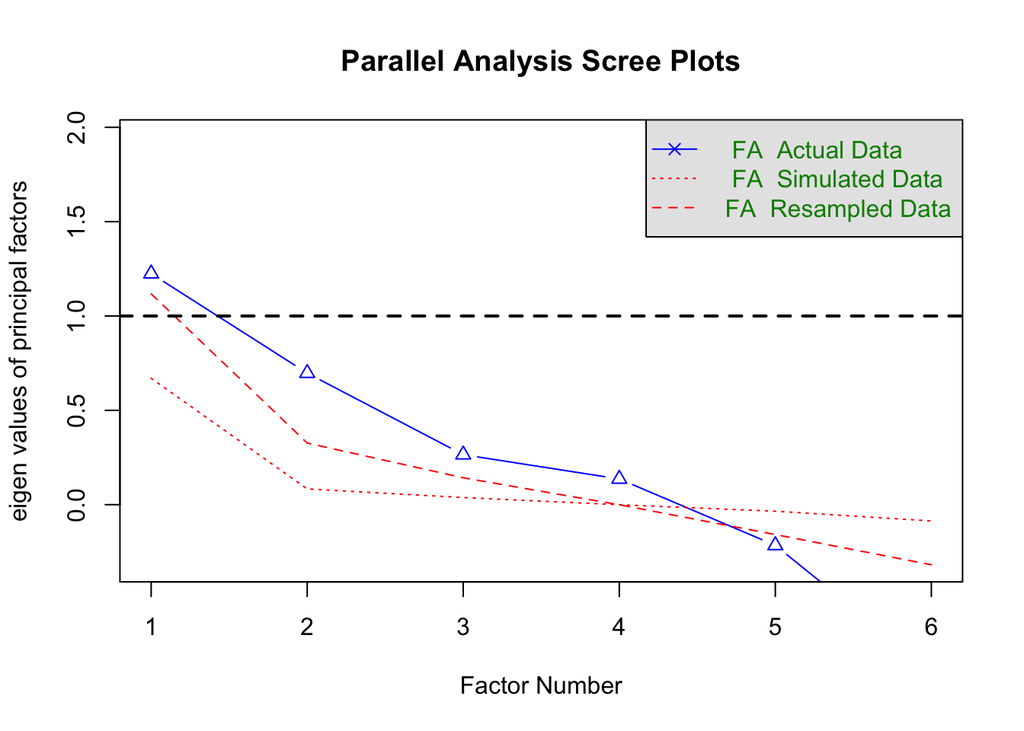

```r
abline(h = 1, col = "black", lty = 2, lwd = 2)
```

## `Scree plot`: : Identificar el número de factores

- Seleccionar el número de factores que incluyan un punto de inflexión

[figure not shown]

## `Eigen values`: Identificar el número de factores

- Eigenvalue (*Representación matemática de la varianza explicada por un grupo de items*)
  - $Eigenvalues > 1$
  - Cuidado:
    - Sobreestima el número de factores
    - Mejor cuando $variables < 30$ y $comunalidades > .70$

```r
m0 <- psych::fa(data_prepare,
                nfactors = 6, # igual al número de ítems
                rotate = "none")

# verificar los eigenvalues mayores que 1
m0$values[m0$values > 1]
```

```
[1] 1.091844
```

## `parameters::n_factor` múltiples formas de evaluar el número de factores

- Comparar resultados con decisiones manuales
- Priorizar el `parallel analysis`, `screeplot` y los `eigenvalues`

```r
prepare_n_factors <- parameters::n_factors(x = data_prepare,
                                         type = "FA",
                                         rotation = "varimax",
                                         algorithm = "minres",
                                         cor = data_cor_mtx)

prepare_n_factors
```

```
# Method Agreement Procedure:

The choice of 3 dimensions is supported by 4 (25.00%) methods out of 16 (Bentler, CNG, Parallel analysis, Kaiser criterion).
```

## `parameters::n_factor` múltiples formas de evaluar el número de factores

```r
parameters::display(prepare_n_factors)
```

| n_Factors | Method | Family |
| --- | --- | --- |
| 0 | Scree (SE) | Scree_SE |
| 0 | Scree (R2) | Scree_SE |
| 1 | Optimal coordinates | Scree |
| 1 | Acceleration factor | Scree |
| 1 | Velicer’s MAP | Velicers_MAP |
| 2 | BIC | BIC |
| 2 | BIC (adjusted) | BIC |
| 3 | Bentler | Bentler |
| 3 | CNG | CNG |
| 3 | Parallel analysis | Scree |
| 3 | Kaiser criterion | Scree |
| 4 | VSS complexity 1 | VSS |
| 5 | Bartlett | Barlett |
| 5 | Anderson | Barlett |
| 5 | Lawley | Barlett |
| 5 | VSS complexity 2 | VSS |

## `parameters::n_factor`: múltiples formas de evaluar el número de factores

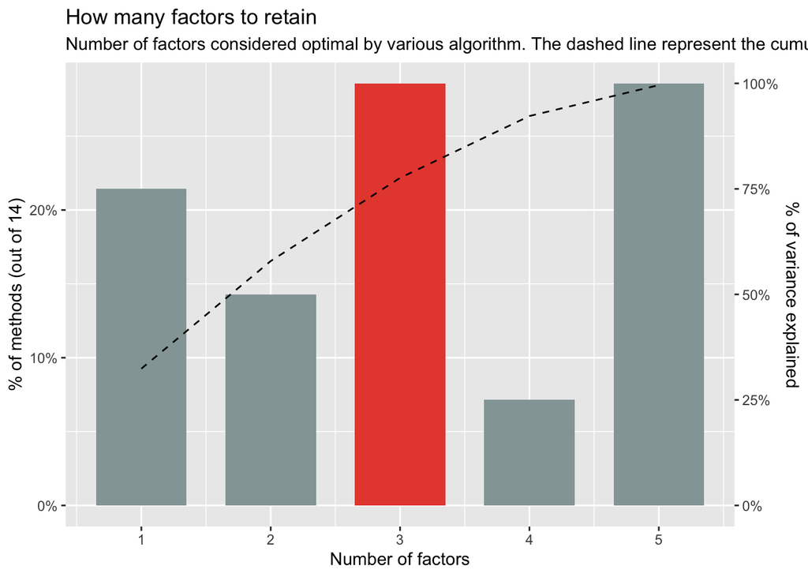

```r
plot(prepare_n_factors)
```

## Seleccionar el método de rotación

- Rotación de factores
  - Maximiza las cargas factoriales en un solo factor y minimizar las cargas en los otros factores.
  - Facilitar la capacidad que tienen los factores para discriminar diferentes atributos
- **Ortogonales**
  - Los factores no están relacionados
  - Maximiza las diferencias, los obliga a no estar asociados
  - *Varimax*, quartimax, equamax
- **Oblicuas**
  - Permite que los factores estén relacionados
  - *Oblimin* y *Promax*

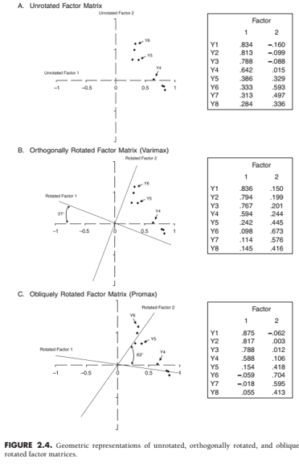

## Estimar el modelo: EFA con dos factores

```r
m1 <- parameters::factor_analysis(
  x = data_prepare,
  n = 2,
  rotation = "oblimin",
  scores = "regression",
  cor = "tet"
)
```

```
In smc, smcs < 0 were set to .0
In smc, smcs < 0 were set to .0
In smc, smcs < 0 were set to .0
```

## Revisar el ajuste del modelo: ajuste global

```r
performance::model_performance(m1) |>
  display()
```

| Chi2(4) | p (Chi2) | RMSR | RMSR_corrected | TLI | RMSEA | RMSEA 90% CI | BIC |
| --- | --- | --- | --- | --- | --- | --- | --- |
| 12574.98 | < .001 | 0.13 | 0.25 | -2.55 | 2.31 | [2.28, 2.34] | 12549.5 |

**Ajuste**

- Solapamiento entre matrices de correlación (modelo vs. datos)

**Desajuste**

- Basado en los residuos
- Diferencia entre las matrices (se prefieren residuos bajos)
- Estadísticos de ajuste (luego en el CFA): RMSEA, SRMR, TLI (Más en el análisis Factorial Confirmatorio)

Algunos valores orientativos:

- RMSR < 0.08 (basado en los errores)
- RMSEA < 0.06
- TLI > 0.95 (o 0.90)
- Chi2 = p > 0.05 (pero este valor casi siempre es significativo)

## Revisar el ajuste del modelo: `residuos` y `normalidad`

- Parecen normales > “Si más del 50% de los residuos están por encima de 0.05; es motivo de preocupación” (Fields, 2026, p. 948)

```r
performance::check_residuals(m1)
```

```
OK: residuals appear as normally distributed (p = 0.332).

Absolute residuals > 0.05 = 8 (53.33%)
```

## Revisar el ajuste del modelo: `residuos` y `normalidad`

- Los residuos están cerca del cero (no hay residuos muy grandes)

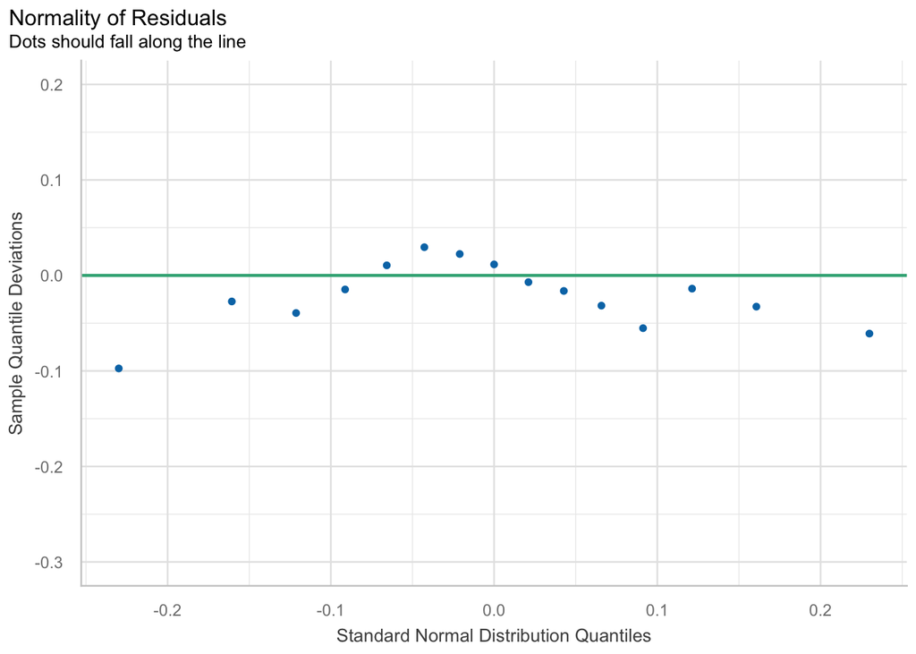

```r
performance::check_normality(m1) |>
  plot()
```

## Inspecionar e interpretar el modelo: `factor loadings`

```r
m1 |>
  parameters::display(threshold = 0.2, # eliminar si quieren ver todas las cargas
                      sort = TRUE)
```

Rotated loadings from Factor Analysis (oblimin-rotation)

| Variable | MR1 | MR2 | Complexity | Uniqueness |
| --- | --- | --- | --- | --- |
| food_prepare_self | 1.06 |  | 1.00 | -0.11 |
| food_prepare_parent_caregiver | 0.40 |  | 1.16 | 0.82 |
| food_prepare_other_family | 0.27 | 0.22 | 1.94 | 0.89 |
| food_prepare_housemates |  | 0.83 | 1.01 | 0.31 |
| food_prepare_friends |  | 0.61 | 1.02 | 0.62 |
| food_prepare_partner | 0.28 | -0.38 | 1.82 | 0.76 |

The 2 latent factors (oblimin rotation) accounted for 45.26% of the total variance of the original data (MR1 = 23.90%, MR2 = 21.36%).

- **Inspeccionar cargas factoriales**
  - Ideal si $\lambda > 0.3|0.4$
  - Problemático si $\lambda > 1.0$
- Como una regresión:
  - Asociación entre el factor y el indicador
  - EFA (factor –> indicador)
  - “El cambio en una unidad estandarizada del factor explica [$b/\lambda$] unidades de cambio en el indicador”
- **Inspeccionar las comunalidades** (*h2*)
  - Cargas factoriales al cuadrado
  - $h_2 = 1$ Toda la varianza compartida (sin varianza única)
  - $h_2 = 0$ Ninguna varianza compartida (toda única)
- **Uniqueness** (*u2*)
  - Varianza única $1 - h_2$
  - Problemátcico si $u^2 < 0$
- **Complexity**
  - Indica si el item carga en más de un factor
  - Ideal si está cerca de 1
  - Problemático si >= 2

## Inspecionar e interpretar el modelo: `Varianza explicada`

```r
m1 |>
  summary()
```

```
# (Explained) Variance of Components

Parameter                       |   MR1 |   MR2
-----------------------------------------------
Eigenvalues                     | 1.612 | 1.198
Variance Explained              | 0.239 | 0.214
Variance Explained (Cumulative) | 0.239 | 0.453
Variance Explained (Proportion) | 0.528 | 0.472

# Factor Correlations

Factor |    MR1 |    MR2
------------------------
MR1    |  1.000 | -0.065
MR2    | -0.065 |  1.000
```

- **SS loadings** (eigenvalues) suma de las cargas factoriales al cuadrado. Representa la varianza explicada por cada factor.
- **Variance Explained**: proporción de la varianza total explicada por cada factor.
- **Variance Explained (Cumulative)**: suma acumulada de la varianza explicada por los factores.
- **Variance Explained (Proportion)**: proporción relativa de varianza explicada por cada factor, considerando solo la varianza explicada por los factores retenidos.

Más información [aquí](https://m-clark.github.io/posts/2020-04-10-psych-explained/)

## Guardar las puntuaciones de los factores (`factor scores`)

- Puntuaciones en cada factor para cada participante
- Se puede usar para otros análisis (ej. regresiones)
- Valores estandarizados
  - Positivo = por encima de la media
  - Negativo = por debajo de la media

```r
m1_scores <- parameters::factor_scores(m1)

head(m1_scores)
```

```
         MR1         MR2
1  2.9391734 -0.33738934
2 -0.3820747 -0.06171308
3 -0.3820747 -0.06171308
4 -0.2979025 -1.01166105
5 -0.3820747 -0.06171308
6 -0.3820747 -0.06171308
```

## Consideraciones finales para seleccionar el modelo

**No todas las soluciones se ajustan bien a los datos**

- Teoría debil
  - Definición deficiente del factor (uno o dos indicadores)
  - Factores sin bases teóricas ni utilidad práctica
- Datos inapropiados
  - Indicadores con *bajas* cargas factoriales en todos los factores
  - Indicadores con *altas* cargas factoriales en varios factores
  - Correlaciones muy bajas o muy altas entre los ítems
  - Indicadores con muy poca (o ninguna) variabilidad

# Ejercicio

## Ejercicio: EFA con hábitos de alimentación

Vamos a adaptar la práctica anterior a un subconjunto de datos llamado `data_eat`, que contiene los ítems de frecuencia de consumo de alimentos:

```r
eat_fruit
eat_vegetables
eat_calcium
eat_white_meat
eat_red_meat
eat_processed_meat
eat_seafood
eat_legumes
eat_sweets
eat_fast_food
eat_convenience_food
eat_home_cooked
eat_breakfast
eat_snacks
```

### Instrucciones

1. Crea el subconjunto `data_eat` con las variables de alimentación.
2. Explora inicialmente los datos: estructura, descriptivos, valores perdidos y distribuciones.
3. Calcula e inspecciona la matriz de correlaciones entre los ítems.
4. Evalúa si los datos son apropiados para un EFA usando funciones del paquete `performance`.
5. Identifica el número de factores con análisis paralelo, eigenvalues y `parameters::n_factors()`.
6. Estima un modelo EFA con rotación oblicua.
7. Revisa la salida del modelo e interpreta las cargas factoriales, comunalidades, varianza explicada y ajuste global.

**Note**

Como los ítems son ordinales, una opción conservadora es usar correlaciones ordinales/policóricas. Para que el ejercicio sea estable en clase, la solución usa correlaciones de Spearman.

# Escribir tu respuesta aquí